# Part II - Baywheels Data Slide Deck Presentation

## by Odafe-Ighele Jesse

## Investigation Overview

> The insights that stood out from the wrangling were;
> - The most popular starting staion and ending station are the same
> - No member made use of the docked bike and there was a general preference for the electric bike
> - March was the best month among the first 3 months of 2022 for the Baywheels bike sharing system and there was a gradual increase in the number of rides across the first 3 months hinting at increasing popularity The key insights answer the following questions;
> - What location is the most popular?
> - Which bike should be purchased if the Baywheels bike sharing system wants to expand its current capacity?
> - Is the method at which services is being carried out working?

## Dataset Overview

> This dataset includes information about individual rides made in the Baywheels bike sharing system covering the greater San Fransisco Bay area in the First 3 months of 2022. The dataset was obtained from https://s3.amazonaws.com/baywheels-data/index.htmlhttps://s3.amazonaws.com/baywheels-data/index.html and multiple files were joined together to obtain a single dataset which was wrangled to make it fit and clean for analysis.

## Which Bike Type takes Lesser Time?

The electric bike was by far the fastest bike on average

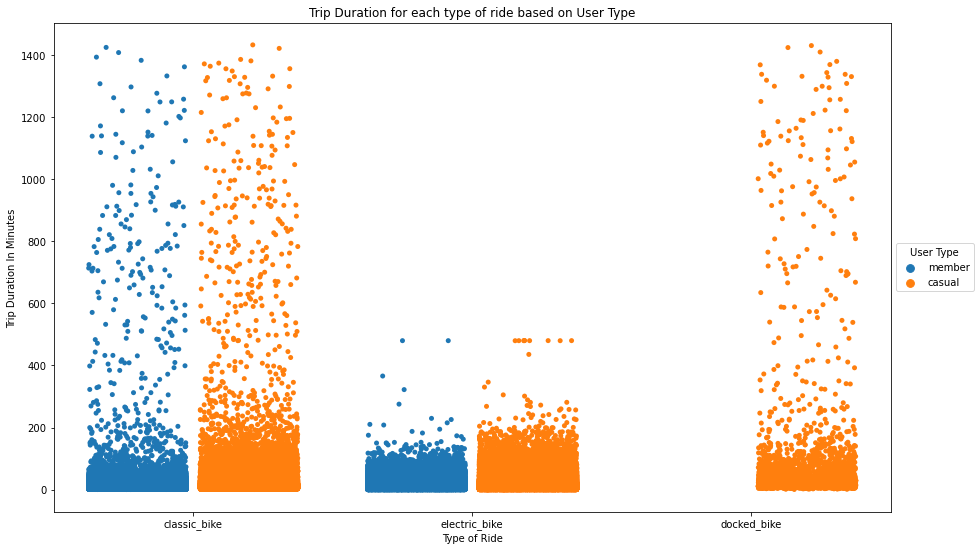

## Which bike should be purchased if the Baywheels bike sharing system wants to expand its current capacity?

The electric bike should be the obvious choice since it takes less time and its prferred by users while the docked bikes should be reduced since it isnt fancied by users

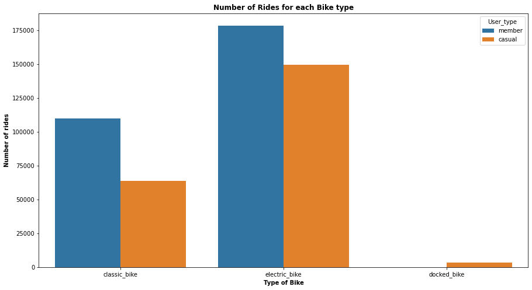

## Which Month had the Quickest ride time on average?

In the month of March,there were quicker(shorter) rides

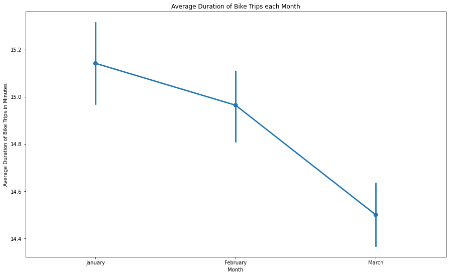

## Is the method at which services is being carried out working?

This is portrayed by a steady increase in the number of rides across the first 3 months of 2022

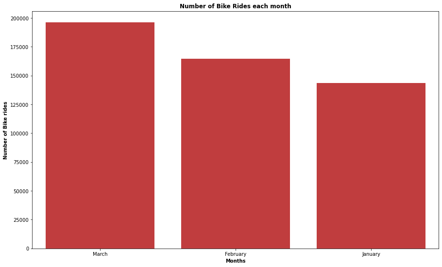